# POLE Remark Criteria - Additional Analysis

#### Item 13 (additional). Report distributions of basic demographic characteristics, standard prognostic variables, and tumor marker, including numbers of missing values.

#### Treatment Trend

Tabulate the proportion of patients receiving different types of initial adjuvant treatment and observe any trend changes over the years.

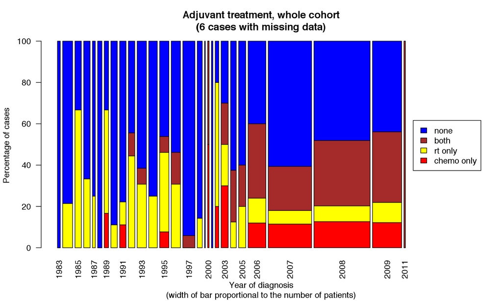

Figure I:

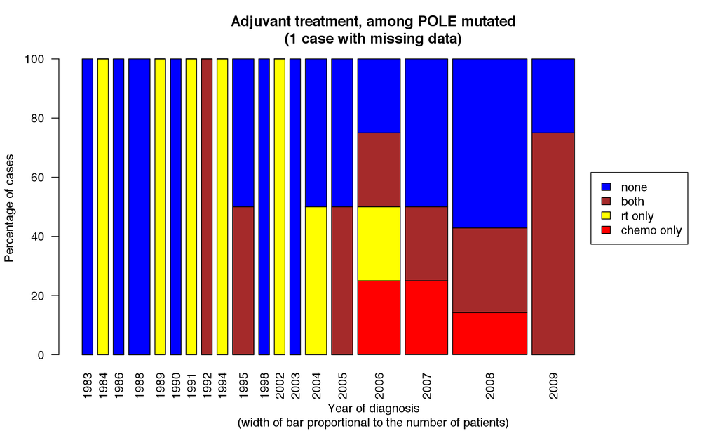

Figure II:

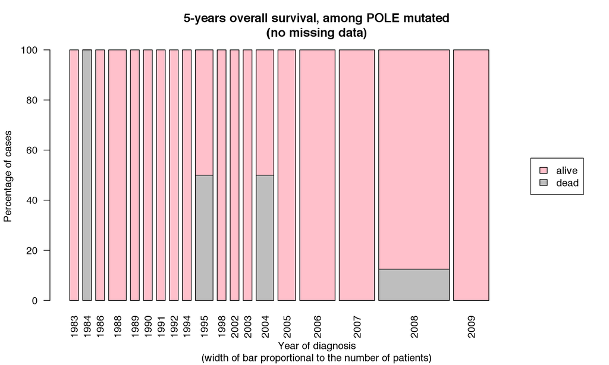

Figure III:

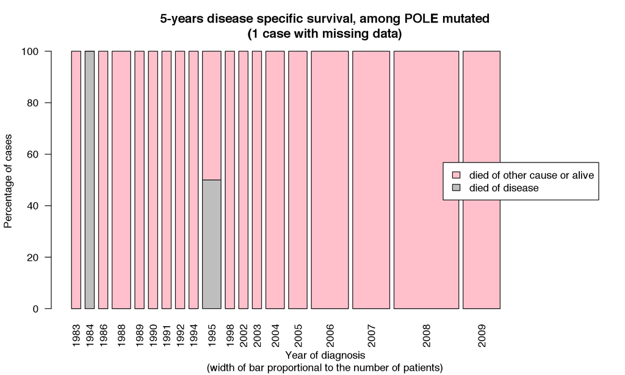

Figure IV:

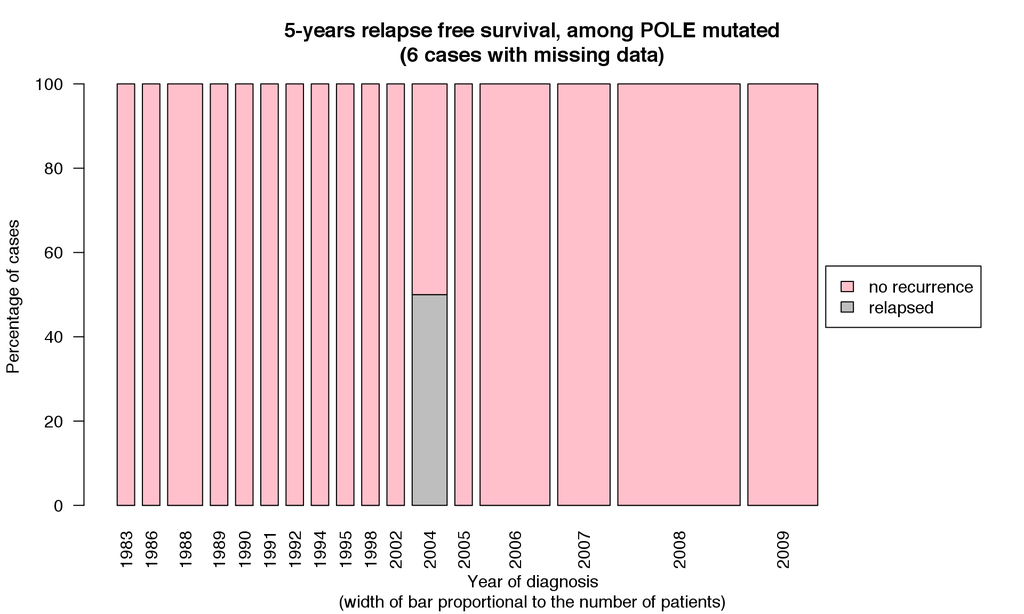

Figure V:

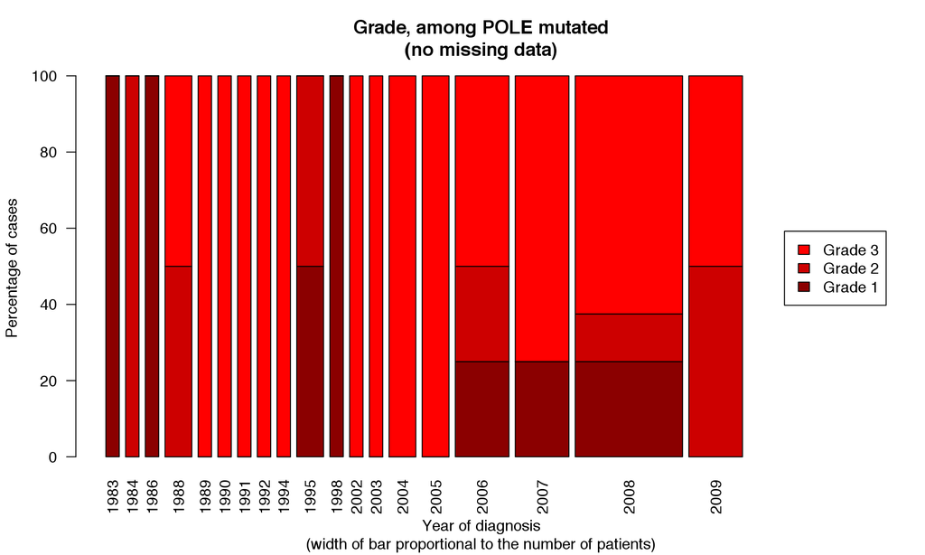

Figure VI:

#### Item 14 (additional). Show the relation of the marker to standard prognostic variables.

#### Logistic Regression Model: POLE ~ clincopathological parameters

Multivariable logistic regression models was used to assess which clinicopathological parameters are most significantly associated with POLE mutation status.

**Model with BMI (GLM)**

Due to lack of cases, the “perfect or quasi perfect separation” problem was encountered when logistic regression model was fitted using glm.

```
##                                                   Estimate    Std. Error
## (Intercept)                                     5.11158958    2.15262360
## age.at.surgery                                 -0.06606916    0.02471222
## bmi                                            -0.10280755    0.04401425
## stage_b1v234II, III or IV                     -18.52565548 1799.15714286
## Tumour.Grade_b12v3Grade 3                      -0.64874083    0.72542776
## Histological.Subtype_non_endoNon-Endometrioid  -0.80200125    0.96534031
## LVSIYes                                         0.42898748    0.61695191
## any.positive.nodesYes                         -13.60840661 2319.36834636
## any.init.treatmentany.treatment                 1.20140464    0.71074376
##                                                   z value    Pr(>|z|)
## (Intercept)                                    2.37458587 0.017568649
## age.at.surgery                                -2.67354204 0.007505487
## bmi                                           -2.33577894 0.019502766
## stage_b1v234II, III or IV                     -0.01029685 0.991784446
## Tumour.Grade_b12v3Grade 3                     -0.89428730 0.371168196
## Histological.Subtype_non_endoNon-Endometrioid -0.83079639 0.406088661
## LVSIYes                                        0.69533374 0.486846175
## any.positive.nodesYes                         -0.00586729 0.995318607
## any.init.treatmentany.treatment                1.69034848 0.090961305
```

Stepwise model selection using AIC (R function step() on glm() fit object) …

```
## Analysis of Deviance Table
##
## Model: binomial, link: logit
##
## Response: POLE.mut.consolidated.numeric
##
## Terms added sequentially (first to last)
##
##
##                    Df Deviance Resid. Df Resid. Dev   Pr(>Chi)
## NULL                                 194    115.426
## age.at.surgery      1   9.5366       193    105.889   0.002014 **
## bmi                 1   7.5576       192     98.331   0.005976 **
## stage_b1v234        1  15.5714       191     82.760 0.00007945 ***
## any.init.treatment  1   2.1633       190     80.597   0.141345
## ---
## Signif. codes:  0 '***' 0.001 '**' 0.01 '*' 0.05 '.' 0.1 ' ' 1
```

**Model with BMI (FIRTH)**

```
## logistf(formula = POLE.mut.consolidated.numeric ~ age.at.surgery +
##     bmi + stage_b1v234 + Tumour.Grade_b12v3 + Histological.Subtype_non_endo +
##     LVSI + any.positive.nodes + any.init.treatment, data = logit.d)
## Model fitted by Penalized ML
## Confidence intervals and p-values by Profile Likelihood
##
##                                                      coef   se(coef)
## (Intercept)                                    4.37810965 1.91547370
## age.at.surgery                                -0.05849073 0.02264658
## bmi                                           -0.08819679 0.03754404
## stage_b1v234II, III or IV                     -3.34171268 1.46343863
## Tumour.Grade_b12v3Grade 3                     -0.55729176 0.65325491
## Histological.Subtype_non_endoNon-Endometrioid -0.62999926 0.84143853
## LVSIYes                                        0.38464113 0.56473353
## any.positive.nodesYes                          0.17881020 1.81097020
## any.init.treatmentany.treatment                1.10355957 0.65976849
##                                               lower 0.95  upper 0.95
## (Intercept)                                    0.6061562  8.49174798
## age.at.surgery                                -0.1062055 -0.01525299
## bmi                                           -0.1763159 -0.01648190
## stage_b1v234II, III or IV                     -9.4427034 -0.95307047
## Tumour.Grade_b12v3Grade 3                     -1.9155608  0.75796977
## Histological.Subtype_non_endoNon-Endometrioid -2.5340378  0.98533906
## LVSIYes                                       -0.7561567  1.52934657
## any.positive.nodesYes                         -5.1697129  4.46264287
## any.init.treatmentany.treatment               -0.2084962  2.45259216
##                                                     Chisq           p
## (Intercept)                                   5.191344415 0.022699650
## age.at.surgery                                7.131365119 0.007574704
## bmi                                           6.162370640 0.013049620
## stage_b1v234II, III or IV                     9.512032900 0.002041289
## Tumour.Grade_b12v3Grade 3                     0.696008814 0.404128049
## Histological.Subtype_non_endoNon-Endometrioid 0.555137749 0.456225978
## LVSIYes                                       0.446542582 0.503981416
## any.positive.nodesYes                         0.006508389 0.935700747
## any.init.treatmentany.treatment               2.730425616 0.098453044
##
## Likelihood ratio test=29.83505 on 8 df, p=0.0002260487, n=195
```

Backward model selection (backward() function from logistf package) …

```
## logistf(formula = POLE.mut.consolidated.numeric ~ age.at.surgery +
##     bmi + stage_b1v234, data = logit.d)
## Model fitted by Penalized ML
## Confidence intervals and p-values by Profile Likelihood
##
##                                  coef   se(coef) lower 0.95  upper 0.95
## (Intercept)                5.12511886 1.84734481  1.5778977  9.02825973
## age.at.surgery            -0.06667439 0.02261049 -0.1143456 -0.02387587
## bmi                       -0.09232873 0.03596839 -0.1749744 -0.02696810
## stage_b1v234II, III or IV -3.19176272 1.44397536 -8.0553160 -1.12203500
##                               Chisq            p
## (Intercept)                8.149534 0.0043072222
## age.at.surgery             9.631251 0.0019129426
## bmi                        8.763374 0.0030733994
## stage_b1v234II, III or IV 12.520455 0.0004025209
##
## Likelihood ratio test=28.40537 on 3 df, p=0.000002985696, n=195
```

**Model excluding BMI (GLM)**

```
##                                                   Estimate    Std. Error
## (Intercept)                                     1.78724148    1.23401199
## age.at.surgery                                 -0.07178324    0.02119301
## stage_b1v234II, III or IV                      -2.10391369    0.81746100
## Tumour.Grade_b12v3Grade 3                       0.54089369    0.55207057
## Histological.Subtype_non_endoNon-Endometrioid  -0.37037996    0.60919794
## LVSIYes                                         0.76051162    0.50064478
## any.positive.nodesYes                         -15.63928217 1046.59861992
## any.init.treatmentany.treatment                 0.88052710    0.56160445
##                                                   z value     Pr(>|z|)
## (Intercept)                                    1.44831776 0.1475282033
## age.at.surgery                                -3.38711927 0.0007063067
## stage_b1v234II, III or IV                     -2.57371749 0.0100612389
## Tumour.Grade_b12v3Grade 3                      0.97975463 0.3272072532
## Histological.Subtype_non_endoNon-Endometrioid -0.60797966 0.5432009622
## LVSIYes                                        1.51906432 0.1287463066
## any.positive.nodesYes                         -0.01494296 0.9880776860
## any.init.treatmentany.treatment                1.56787771 0.1169096747
```

Stepwise model selection using AIC (R function step() on glm() fit object) …

```
## Analysis of Deviance Table
##
## Model: binomial, link: logit
##
## Response: POLE.mut.consolidated.numeric
##
## Terms added sequentially (first to last)
##
##
##                    Df Deviance Resid. Df Resid. Dev  Pr(>Chi)
## NULL                                 243     165.56
## age.at.surgery      1  14.7743       242     150.78 0.0001212 ***
## stage_b1v234        1   9.1904       241     141.59 0.0024328 **
## LVSI                1   5.5575       240     136.03 0.0184021 *
## any.positive.nodes  1   2.6249       239     133.41 0.1052017
## any.init.treatment  1   3.7692       238     129.64 0.0522044 .
## ---
## Signif. codes:  0 '***' 0.001 '**' 0.01 '*' 0.05 '.' 0.1 ' ' 1
```

**Model excluding BMI (FIRTH)**

```
##                                                 coef exp(coef) lower 0.95
## (Intercept)                                    1.616     5.034      0.496
## age.at.surgery                                -0.067     0.935      0.897
## stage_b1v234II, III or IV                     -1.878     0.153      0.027
## Tumour.Grade_b12v3Grade 3                      0.512     1.668      0.589
## Histological.Subtype_non_endoNon-Endometrioid -0.330     0.719      0.218
## LVSIYes                                        0.718     2.051      0.792
## any.positive.nodesYes                         -1.601     0.202      0.001
## any.init.treatmentany.treatment                0.845     2.327      0.798
##                                               upper 0.95     p
## (Intercept)                                       54.201 0.171
## age.at.surgery                                     0.972 0.000
## stage_b1v234II, III or IV                          0.574 0.004
## Tumour.Grade_b12v3Grade 3                          4.830 0.334
## Histological.Subtype_non_endoNon-Endometrioid      2.194 0.567
## LVSIYes                                            5.351 0.138
## any.positive.nodesYes                              2.455 0.234
## any.init.treatmentany.treatment                    6.834 0.121
```

Backward model selection (backward() function from logistf package) …

```
## logistf(formula = POLE.mut.consolidated.numeric ~ age.at.surgery +
##     stage_b1v234 + any.init.treatment, data = logit.ex.bmi.d)
## Model fitted by Penalized ML
## Confidence intervals and p-values by Profile Likelihood
##
##                                        coef   se(coef) lower 0.95
## (Intercept)                      1.75792690 1.15914961 -0.5043112
## age.at.surgery                  -0.06405604 0.01944541 -0.1042480
## stage_b1v234II, III or IV       -2.33843037 0.72718875 -4.0167631
## any.init.treatmentany.treatment  1.18797771 0.46850670  0.2817439
##                                  upper 0.95     Chisq            p
## (Intercept)                      4.07911981  2.321338 0.1276102113
## age.at.surgery                  -0.02710771 11.955755 0.0005447886
## stage_b1v234II, III or IV       -1.05933082 14.458147 0.0001433087
## any.init.treatmentany.treatment  2.12414401  6.586293 0.0102766918
##
## Likelihood ratio test=29.26071 on 3 df, p=0.000001974003, n=244
```

**Summary of logistic regression analysis**

- Model with BMI shows age, BMI and stage significantly (both glm and logistf) associated with POLE mutation status.
- Model excluding BMI shows age and stage significantly (both glm and logistf) associated with POLE mutation status.

**Cross tabulation tables …**

Table 1: POLE vs. Stage x Age

|  |  | Total | POLE wild type | POLE mutated | association/correlation test |
| --- | --- | --- | --- | --- | --- |
| Total |  | 406 (100%) | 367 (90%) | 39 (10%) |  |
| Stage x age |  |  |  |  | Fisher’s exact test P = 0.0000 |
|  | Stage I / <=60 yrs row% col% | 105 (26%) | 82 78% 23% | 23 22% 61% |  |
|  | Stage I / >60 yrs row% col% | 179 (45%) | 166 93% 46% | 13 7% 34% |  |
|  | Stage II, III or IV / <=60 yrs row% col% | 30 (7%) | 29 97% 8% | 1 3% 3% |  |
|  | Stage II, III or IV / >60 yrs row% col% | 88 (22%) | 87 99% 24% | 1 1% 3% |  |
|  | missing | 4 | 3 | 1 |  |

Table 2: POLE vs. Stage x BMI

|  |  | Total | POLE wild type | POLE mutated | association/correlation test |
| --- | --- | --- | --- | --- | --- |
| Total |  | 406 (100%) | 367 (90%) | 39 (10%) |  |
| Stage x BMI |  |  |  |  | Fisher’s exact test P = 0.0005 |
|  | Stage I / <30 bmi row% col% | 66 (31%) | 53 80% 28% | 13 20% 68% |  |
|  | Stage I / >=30 bmi row% col% | 69 (33%) | 63 91% 33% | 6 9% 32% |  |
|  | Stage II, III or IV / <30 bmi row% col% | 44 (21%) | 44 100% 23% | 0 0% 0% |  |
|  | Stage II, III or IV / >=30 bmi row% col% | 31 (15%) | 31 100% 16% | 0 0% 0% |  |
|  | missing | 196 | 176 | 20 |  |

Table 3: POLE vs. age x BMI

|  |  | Total | POLE wild type | POLE mutated | association/correlation test |
| --- | --- | --- | --- | --- | --- |
| Total |  | 406 (100%) | 367 (90%) | 39 (10%) |  |
| Age x BMI |  |  |  |  | Fisher’s exact test P = 0.0217 |
|  | age <=60 yrs / <30 bmi row% col% | 31 (15%) | 24 77% 13% | 7 23% 37% |  |
|  | age <=60 yrs / >=30 bmi row% col% | 36 (17%) | 32 89% 17% | 4 11% 21% |  |
|  | age >60 yrs / <30 bmi row% col% | 79 (38%) | 73 92% 38% | 6 8% 32% |  |
|  | age >60 yrs / >=30 bmi row% col% | 64 (30%) | 62 97% 32% | 2 3% 11% |  |
|  | missing | 196 | 176 | 20 |  |

Table 4: POLE vs. Stage x age x BMI

|  |  | Total | POLE wild type | POLE mutated | association/correlation test |
| --- | --- | --- | --- | --- | --- |
| Total |  | 406 (100%) | 367 (90%) | 39 (10%) |  |
| Stage x age x BMI |  |  |  |  | Fisher’s exact test P = 0.0017 |
|  | Stage I / <=60 yrs / <30 bmi row% col% | 22 (10%) | 15 68% 8% | 7 32% 37% |  |
|  | Stage I / <=60 yrs / >=30 bmi row% col% | 27 (13%) | 23 85% 12% | 4 15% 21% |  |
|  | Stage I / >60 yrs / <30 bmi row% col% | 44 (21%) | 38 86% 20% | 6 14% 32% |  |
|  | Stage I / >60 yrs / >=30 bmi row% col% | 42 (20%) | 40 95% 21% | 2 5% 11% |  |
|  | Stage II, III or IV / <=60 yrs / <30 bmi row% col% | 9 (4%) | 9 100% 5% | 0 0% 0% |  |
|  | Stage II, III or IV / <=60 yrs / >=30 bmi row% col% | 9 (4%) | 9 100% 5% | 0 0% 0% |  |
|  | Stage II, III or IV / >60 yrs / <30 bmi row% col% | 35 (17%) | 35 100% 18% | 0 0% 0% |  |
|  | Stage II, III or IV / >60 yrs / >=30 bmi row% col% | 22 (10%) | 22 100% 12% | 0 0% 0% |  |
|  | missing | 196 | 176 | 20 |  |

#### Item 15 (additional). Present univariable analyses showing the relation between the marker and outcome, with the estimated effect. Preferrably provide similar analyses for all other variables being analyzed.

**Analysis among grade 3 - univariable**

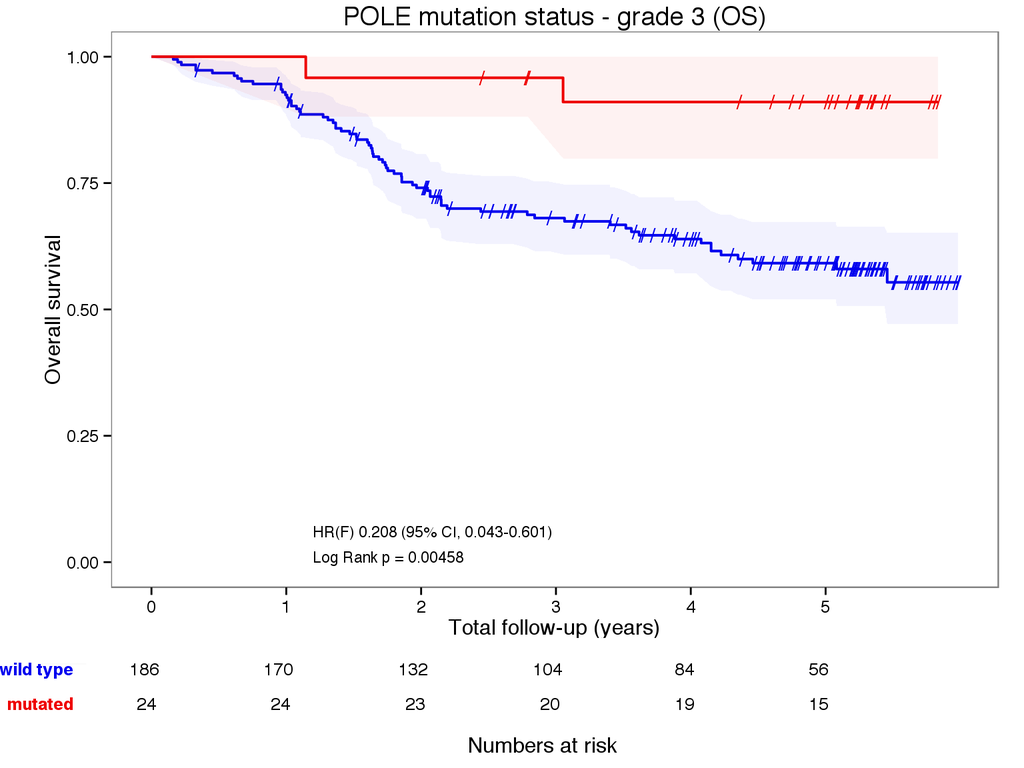

Figure VII:

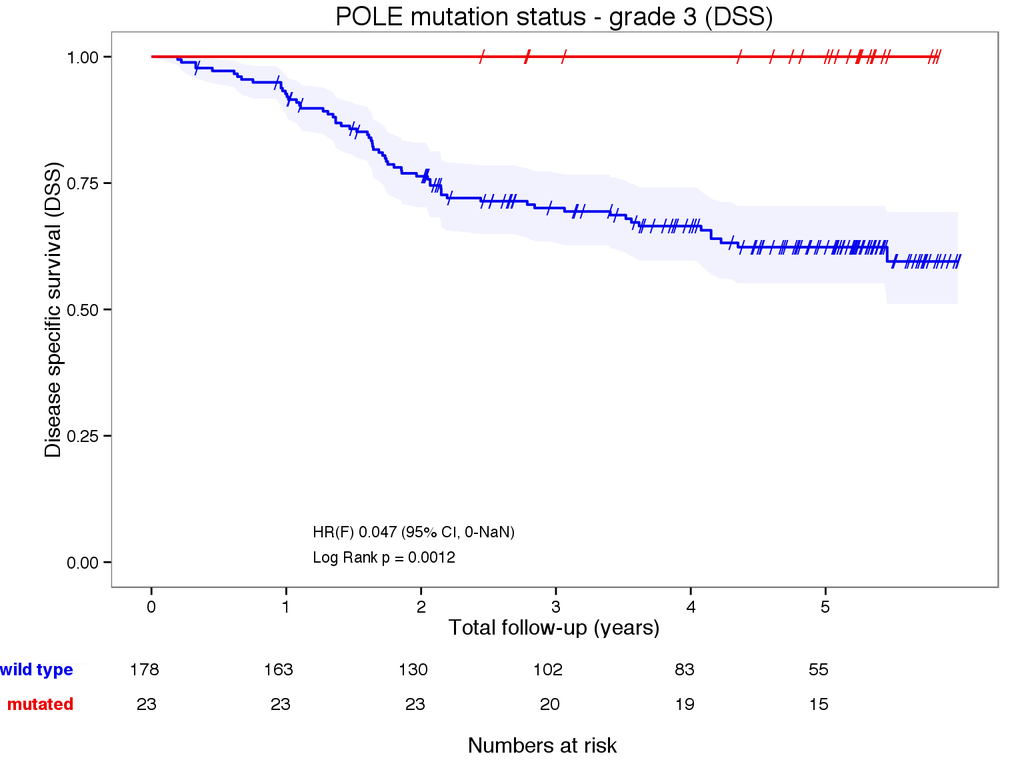

Figure VIII:

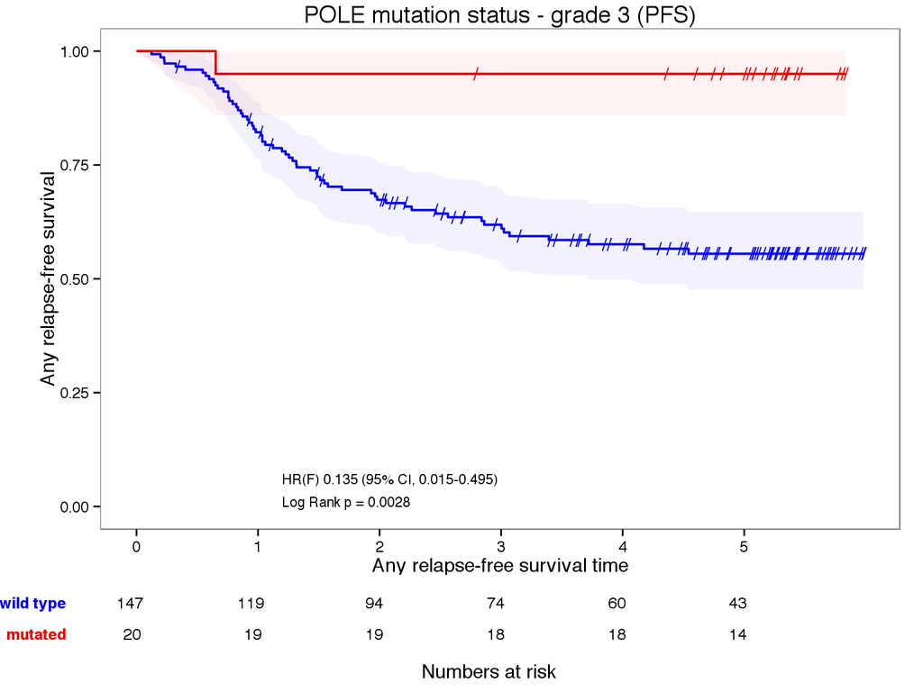

Figure IX:

*Please note: (F) indicates that the Firth’s penalized maximum likelihood bias reduction method was used to estimate the hazard ratio.*

Table 5: Univariable analyses of relation of POLE mutation status to OS/DSS/RFS among patients with grade 3 tumors

|  |  | # of events / n | Hazard Ratio (95% CI) | LRT P-value |
| --- | --- | --- | --- | --- |
| POLE mutation status wild type=0/mutated=1 | OS | 73 / 210 | 0.21 (0.04-0.60)<sup>F</sup> | 0.0007 |
|  | DSS | 62 / 201 | 0.05 (0.00-NA)<sup>F</sup> | 0.0000 |
|  | PFS | 62 / 167 | 0.14 (0.02-0.50)<sup>F</sup> | 0.0002 |

**Analysis among grade 3 - multivariable**

Table 6: Multivariable analyses of POLE (exclude BMI) among grade 3

|  |  | # of events / n | Hazard Ratio (95% CI) | LRT P-value |
| --- | --- | --- | --- | --- |
| OS | POLE mutation status wild type (reference) vs. mutated | 51 / 153 | 0.72 (0.14-2.37)<sup>F</sup> | 0.4654 |
|  | Age at surgery continuous |  | 1.03 (1.00-1.07)<sup>F</sup> | 0.0283 |
|  | Stage I (reference) vs. {II, III or IV} |  | 3.66 (1.62-8.76)<sup>F</sup> | 0.0013 |
|  | Histological subtype endometrioid (reference) vs. non-endometrioid |  | 0.99 (0.54-1.84)<sup>F</sup> | 0.9806 |
|  | Lymphovascular invasion (no lymphovascular invasion as reference) |  | 2.43 (1.17-5.37)<sup>F</sup> | 0.0145 |
|  | Any positive nodes (no positive nodes as reference) |  | 0.83 (0.42-1.59)<sup>F</sup> | 0.5615 |
|  | Any initial adjuvant treatment (no treatment as reference) |  | 0.62 (0.27-1.46)<sup>F</sup> | 0.2830 |
| DSS | POLE mutation status wild type (reference) vs. mutated | 42 / 145 | 0.16 (0.00-1.25)<sup>F</sup> | 0.0221 |
|  | Age at surgery continuous |  | 1.02 (0.99-1.06)<sup>F</sup> | 0.1424 |
|  | Stage I (reference) vs. {II, III or IV} |  | 4.67 (1.86-12.89)<sup>F</sup> | 0.0007 |
|  | Histological subtype endometrioid (reference) vs. non-endometrioid |  | 1.07 (0.55-2.11)<sup>F</sup> | 0.8520 |
|  | Lymphovascular invasion (no lymphovascular invasion as reference) |  | 2.62 (1.15-6.54)<sup>F</sup> | 0.0177 |
|  | Any positive nodes (no positive nodes as reference) |  | 0.79 (0.39-1.58)<sup>F</sup> | 0.4957 |
|  | Any initial adjuvant treatment (no treatment as reference) |  | 0.57 (0.23-1.54)<sup>F</sup> | 0.2880 |
| PFS | POLE mutation status wild type (reference) vs. mutated | 53 / 131 | 0.28 (0.03-1.14)<sup>F</sup> | 0.0431 |
|  | Age at surgery continuous |  | 1.01 (0.98-1.04)<sup>F</sup> | 0.5926 |
|  | Stage I (reference) vs. {II, III or IV} |  | 2.56 (1.17-5.72)<sup>F</sup> | 0.0178 |
|  | Histological subtype endometrioid (reference) vs. non-endometrioid |  | 1.22 (0.69-2.19)<sup>F</sup> | 0.4905 |
|  | Lymphovascular invasion (no lymphovascular invasion as reference) |  | 2.27 (1.12-4.81)<sup>F</sup> | 0.0210 |
|  | Any positive nodes (no positive nodes as reference) |  | 0.89 (0.46-1.73)<sup>F</sup> | 0.7294 |
|  | Any initial adjuvant treatment (no treatment as reference) |  | 0.64 (0.31-1.38)<sup>F</sup> | 0.2709 |

There is a discrepancy between likelihood ratio test (table 6) and the P-values from Wald test (not shown, but implied by the reported hazard ratio confidence interval in table 6. i.e. we expected to see the confidence interval to not cross “1”" for all parameters with likelihood ratio test p-values < 0.05). Steve McKinney suggested a bootstrap analysis be performed to observe how the hazard ratio will be distributed on bootstrap samples. For example, if 97.5% of the hazard ratios obtained from bootstrap samples are above “1”, we will be able to say that the hazard ratio is significantly greater than “1”, p=0.05.

*Bootstrap analysis - hazard ratio from Cox regression models with Firth’s penalized likelihood*

Number of bootstrap samples: 1000

Table 7. Median (overall survival) hazard ratio and 95% CI among 1000 bootstrap samples

| variable | hazard ratio (95% CI) |
| --- | --- |
| POLE.mut.consolidated.numeric | 0.46 (0.07 to 1.59) |
| age.at.surgery | 1.03 (1 to 1.06) |
| stage_b1v234 | 3.44 (1.77 to 9.12) |
| Histological.Subtype_non_endo | 0.95 (0.52 to 1.7) |
| LVSI | 1.7 (0.94 to 3.2) |
| any.positive.nodes_tested | 0.96 (0.69 to 1.32) |
| any.init.treatment | 0.83 (0.33 to 1.97) |

Table 8. Median (disease specific survival) hazard ratio and 95% CI among 1000 bootstrap samples

| variable | hazard ratio (95% CI) |
| --- | --- |
| POLE.mut.consolidated.numeric | 0.11 (0.05 to 0.26) |
| age.at.surgery | 1.02 (1 to 1.05) |
| stage_b1v234 | 3.69 (1.66 to 10.21) |
| Histological.Subtype_non_endo | 0.95 (0.5 to 1.74) |
| LVSI | 1.88 (0.94 to 3.97) |
| any.positive.nodes_tested | 0.97 (0.68 to 1.38) |
| any.init.treatment | 0.83 (0.29 to 2.21) |

Table 9. Median (progression free survival) hazard ratio and 95% CI among 1000 bootstrap samples

| variable | hazard ratio (95% CI) |
| --- | --- |
| POLE.mut.consolidated.numeric | 0.22 (0.05 to 0.84) |
| age.at.surgery | 1 (0.98 to 1.03) |
| stage_b1v234 | 3.53 (1.82 to 8.42) |
| Histological.Subtype_non_endo | 1.19 (0.65 to 2.23) |
| LVSI | 1.87 (0.95 to 3.88) |
| any.positive.nodes_tested | 0.88 (0.63 to 1.22) |
| any.init.treatment | 0.76 (0.27 to 1.61) |

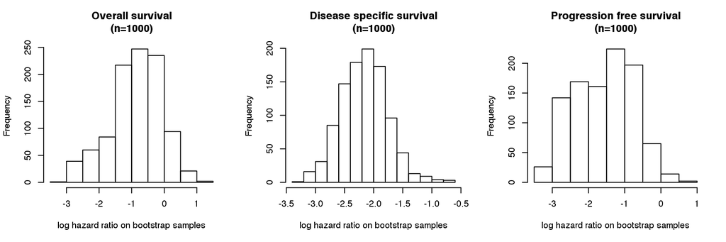

Figure X: